# Programming basics for Biostatistics 6099

Numpy Advanced

Zhiguang Huo (Caleb)

Tuesday Nov 7th, 2023

# Outlines

- reshape and flatten
- concatenating and splitting
- repeat and tile
- take and put
- broadcasting
- aggregation
- file save and load

# reshape and flatten

```python
import numpy as np

x = np.zeros(8).reshape(2,4)
x
```

```
## array([[0., 0., 0., 0.],
##        [0., 0., 0., 0.]])
```

```python
x.reshape(4,-1)
```

```
## array([[0., 0.],
##        [0., 0.],
##        [0., 0.],
##        [0., 0.]])
```

```python
x.flatten()
```

```
## array([0., 0., 0., 0., 0., 0., 0., 0.])
```

```python
x.ravel()
```

```
## array([0., 0., 0., 0., 0., 0., 0., 0.])
```

# Concatenating

- concatenate(): combine two np.array together

```python
x = np.zeros(6).reshape(2,3); x
```

```
## array([[0., 0., 0.],
##        [0., 0., 0.]])
```

```python
y = np.ones(6).reshape(2,3); y
```

```
## array([[1., 1., 1.],
##        [1., 1., 1.]])
```

```python
np.concatenate([x,y],axis=0) ## axis=0 is default
```

```
## array([[0., 0., 0.],
##        [0., 0., 0.],
##        [1., 1., 1.],
##        [1., 1., 1.]])
```

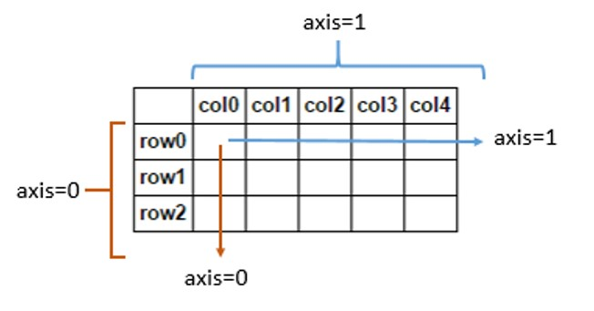

```python
np.concatenate([x,y],axis=1)
```

```
## array([[0., 0., 0., 1., 1., 1.],
##        [0., 0., 0., 1., 1., 1.]])
```

# Concatenating

- vstack and hstack

```python
np.vstack([x,y])
```

```
## array([[0., 0., 0.],
##        [0., 0., 0.],
##        [1., 1., 1.],
##        [1., 1., 1.]])
```

```python
np.hstack([x,y])
```

```
## array([[0., 0., 0., 1., 1., 1.],
##        [0., 0., 0., 1., 1., 1.]])
```

# Concatenating

- c_ and r_: [] instead of ()

```python
np.c_[x,y]
```

```
## array([[0., 0., 0., 1., 1., 1.],
##        [0., 0., 0., 1., 1., 1.]])
```

```python
np.r_[x,y]
```

```
## array([[0., 0., 0.],
##        [0., 0., 0.],
##        [1., 1., 1.],
##        [1., 1., 1.]])
```

# Splitting

```python
rng = np.random.default_rng(32608)
data = rng.standard_normal((5,2))
np.split(data, [2]) ## default: axis = 0
```

```
## [array([[ 0.21984492, -1.28342596],
##        [ 1.31520866,  0.85478637]]), array([[-1.12501008, -2.36333542],
##        [ 1.72194583, -1.29984418],
##        [ 0.82499496,  0.55837717]])]
```

```python
x, y = np.split(data, [2])
x
```

```
## array([[ 0.21984492, -1.28342596],
##        [ 1.31520866,  0.85478637]])
```

```python
y
```

```
## array([[-1.12501008, -2.36333542],
##        [ 1.72194583, -1.29984418],
##        [ 0.82499496,  0.55837717]])
```

# Splitting

```python
x, y, z = np.split(data, [1,3])
x;y;z
```

```
## array([[ 0.21984492, -1.28342596]])
## array([[ 1.31520866,  0.85478637],
##        [-1.12501008, -2.36333542]])
## array([[ 1.72194583, -1.29984418],
##        [ 0.82499496,  0.55837717]])
```

```python
a, b = np.split(data, [1],axis=1)
a;b
```

```
## array([[ 0.21984492],
##        [ 1.31520866],
##        [-1.12501008],
##        [ 1.72194583],
##        [ 0.82499496]])
## array([[-1.28342596],
##        [ 0.85478637],
##        [-2.36333542],
##        [-1.29984418],
##        [ 0.55837717]])
```

# Splitting

```python
x, y, z = np.vsplit(data, [1,3])
x;y;z
```

```
## array([[ 0.21984492, -1.28342596]])
## array([[ 1.31520866,  0.85478637],
##        [-1.12501008, -2.36333542]])
## array([[ 1.72194583, -1.29984418],
##        [ 0.82499496,  0.55837717]])
```

```python
a, b = np.hsplit(data, [1])
a;b
```

```
## array([[ 0.21984492],
##        [ 1.31520866],
##        [-1.12501008],
##        [ 1.72194583],
##        [ 0.82499496]])
## array([[-1.28342596],
##        [ 0.85478637],
##        [-2.36333542],
##        [-1.29984418],
##        [ 0.55837717]])
```

# repeat (1darray)

- repeat replicates each element of np.array some number of times
  - if pass in an integer, each element will be repeated that number of times
  - if pass in an array, each element will be repeated the number of times specified in the array

```python
data = np.array([1,2,3])
data.repeat(2)
```

```
## array([1, 1, 2, 2, 3, 3])
```

```python
data.repeat([2,3,4])
```

```
## array([1, 1, 2, 2, 2, 3, 3, 3, 3])
```

# repeat (2darray)

```python
data = np.arange(1,5).reshape(2,2)
data.repeat(2) ## default, flatten the array
```

```
## array([1, 1, 2, 2, 3, 3, 4, 4])
```

```python
data.repeat(2, axis=0)
```

```
## array([[1, 2],
##        [1, 2],
##        [3, 4],
##        [3, 4]])
```

```python
data.repeat(2, axis=1)
```

```
## array([[1, 1, 2, 2],
##        [3, 3, 4, 4]])
```

```python
data.repeat([2,3], axis=1)
```

```
## array([[1, 1, 2, 2, 2],
##        [3, 3, 4, 4, 4]])
```

# tile

- tile is to stack copies of an array along an axis
  - laying down tiles

```python
data = np.arange(1,5).reshape(2,2)
np.tile(data, 2)
```

```
## array([[1, 2, 1, 2],
##        [3, 4, 3, 4]])
```

```python
np.tile(data, (2,1)) ## 2 rows and 1 column -- tiles
```

```
## array([[1, 2],
##        [3, 4],
##        [1, 2],
##        [3, 4]])
```

```python
np.tile(data, (3,2))
```

```
## array([[1, 2, 1, 2],
##        [3, 4, 3, 4],
##        [1, 2, 1, 2],
##        [3, 4, 3, 4],
##        [1, 2, 1, 2],
##        [3, 4, 3, 4]])
```

# Take and put (alternative to fancy indexing)

- take: get elements

```python
data = np.arange(0,100,10); data
```

```
## array([ 0, 10, 20, 30, 40, 50, 60, 70, 80, 90])
```

```python
inds = [9,5,2,7]
data[inds]
```

```
## array([90, 50, 20, 70])
```

```python
data.take(inds)
```

```
## array([90, 50, 20, 70])
```

# Take and put (alternative to fancy indexing)

- put: assignment elements

```python
data = np.arange(0,100,10); data
```

```
## array([ 0, 10, 20, 30, 40, 50, 60, 70, 80, 90])
```

```python
inds = [9,5,2,7]
data.put(inds, -99)
data
```

```
## array([  0,  10, -99,  30,  40, -99,  60, -99,  80, -99])
```

```python
data.put(inds, [0,1,2,3])
data
```

```
## array([ 0, 10,  2, 30, 40,  1, 60,  3, 80,  0])
```

# Take and put (2darray)

- for 2d np.array

```python
data = np.arange(12).reshape(3,-1)
ind = [1,1,0,0]
data.take(ind, axis=None) ## default
```

```
## array([1, 1, 0, 0])
```

```python
data.take(ind, axis=0)
```

```
## array([[4, 5, 6, 7],
##        [4, 5, 6, 7],
##        [0, 1, 2, 3],
##        [0, 1, 2, 3]])
```

```python
data.take(ind, axis=1)
```

```
## array([[1, 1, 0, 0],
##        [5, 5, 4, 4],
##        [9, 9, 8, 8]])
```

# Broadcasting

Broadcasting is about arithmetic work between arrays with different shapes.

- 1d array and scalar
  - broadcast the scalar to the array (with the same shape)

```python
data = np.arange(6)
data * 5
```

```
## array([ 0,  5, 10, 15, 20, 25])
```

- manually convert the scalar to the array

```python
np.full(6,5)
```

```
## array([5, 5, 5, 5, 5, 5])
```

```python
data * np.full(6,5)
```

```
## array([ 0,  5, 10, 15, 20, 25])
```

# Broadcasting

- broadcast the 1d array to the 2d array
  - the trailing dimension (e.g., 2) of the 2d array (3,2) match the length of the 1d array (e.g., shape=(2,))

```python
data2d = np.arange(6).reshape(3,2)
vec1d = np.arange(2)
data2d + vec1d
```

```
## array([[0, 2],
##        [2, 4],
##        [4, 6]])
```

- same as this (broadcasting the 1d array to the 2d array with the same shape)

```python
vec2d = np.tile(vec1d,(3,1))
vec2d
```

```
## array([[0, 1],
##        [0, 1],
##        [0, 1]])
```

```python
data2d + vec2d
```

```
## array([[0, 2],
##        [2, 4],
##        [4, 6]])
```

# Broadcasting

- broadcast the 1d array to the 2d array
  - the staring dimension (e.g., 3) of the 2d array (3,2) match the length of the 1d array (e.g., shape=(3,1))
  - the 1d array should be shaped as of dimension (n, **1**)

```python
data2d = np.arange(6).reshape(3,2)
vec1d = np.arange(3).reshape(3,1)
data2d + vec1d
```

```
## array([[0, 1],
##        [3, 4],
##        [6, 7]])
```

- same as this (broadcasting the 1d array to the 2d array with the same shape)

```python
vec2d = np.tile(vec1d,(1,2))
vec2d
```

```
## array([[0, 0],
##        [1, 1],
##        [2, 2]])
```

```python
data2d + vec2d
```

```
## array([[0, 1],
##        [3, 4],
##        [6, 7]])
```

# Broadcasting

- This will not work

```
data2d = np.arange(6).reshape(3,2)
vec1d = np.arange(3)
data2d + vec1d
```

# Broadcasting (exercise)

- the following array is given

```python
data2d = np.arange(12).reshape(4,3)
data2d
```

```
## array([[ 0,  1,  2],
##        [ 3,  4,  5],
##        [ 6,  7,  8],
##        [ 9, 10, 11]])
```

- calculate the row means (mean value for each row)
  - subtract the row means from data2d (from each column of data2d)
- calculate the column means (mean value for each column)
  - subtract the column means from data2d (from each row of data2d)

# Broadcasting (solution to the exercise)

- subtract the row means from data2d

```python
data2d - data2d.mean(axis=1).reshape(4,1)
```

```
## array([[-1.,  0.,  1.],
##        [-1.,  0.,  1.],
##        [-1.,  0.,  1.],
##        [-1.,  0.,  1.]])
```

- subtract the column means from data2d

```python
data2d - data2d.mean(axis=0)
```

```
## array([[-4.5, -4.5, -4.5],
##        [-1.5, -1.5, -1.5],
##        [ 1.5,  1.5,  1.5],
##        [ 4.5,  4.5,  4.5]])
```

# create a new dimension

- use reshape
- use np.newaxis

```python
data = np.ones((3,3))
data_3d = data.reshape(3,1,3)
data_3d = data[:,np.newaxis,:]
data_3d.shape
```

```
## (3, 1, 3)
```

# 3d array

```python
rng = np.random.default_rng(32608)
data3d = rng.standard_normal((2,3,4))
data3d.shape
```

```
## (2, 3, 4)
```

```python
depth_means = data3d.mean(axis=2) ## row, column, depth
depth_means
```

```
## array([[ 0.2766035 , -0.76656096, -0.01555895],
##        [-0.7650591 ,  0.12205003,  0.13344552]])
```

```python
demeaned = data3d - depth_means[:,:,np.newaxis]
demeaned.mean(2)
```

```
## array([[ 0.00000000e+00, -5.55111512e-17,  1.11022302e-16],
##        [ 0.00000000e+00, -2.77555756e-17,  1.38777878e-17]])
```

# data aggregation

- reduce and accumulate methods: recuisively apply a binary ufuncs to the array
  - f(1,2); f(f(1,2),3), etc

```python
data = np.arange(1,5)
np.add(data[0], data[1])
```

```
## 3
```

```python
np.add.reduce(data)
```

```
## 10
```

```python
np.add.accumulate(data)
```

```
## array([ 1,  3,  6, 10])
```

```python
np.cumsum(data)
```

```
## array([ 1,  3,  6, 10])
```

```python
np.multiply.reduce(data)
```

```
## 24
```

```python
np.multiply.accumulate(data)
```

```
## array([ 1,  2,  6, 24])
```

```python
np.cumprod(data)
```

```
## array([ 1,  2,  6, 24])
```

# numpy file save and load

- np.save will save the numpy data in binary format, which is efficient
- save single numpy object
  - extension: npy

```
data = np.arange(1,10)
np.save("my_data.npy", data)
np.load("my_data.npy")
```

- save multiple numpy objects
  - extension: npz

```
data1 = np.arange(1,10); data2 = np.arange(2,11);
np.savez("my_data2.npz", x=data1, y=data2)
dat = np.load("my_data2.npz")
dat["x"]
dat["y"]
```

# Reference

- https://wesmckinney.com/book/advanced-numpy.html